# Titanic_Survival

Ivan

24 août 2017

## Get familiar with the dataset

Of course we want to read the data and put it in a structure so we can start our analysis. Here we chose a data.table, which is, to keep it simple, an enhanced data.frame. If you are interested, I’m sure you will succeed in finding more on your own (Google).

```r
trainDt <- fread("train.csv", sep = ",", header = T,
                 na.strings = "", stringsAsFactors = T)
testDt <- fread("test.csv", sep = ",", header = T,
                na.strings = "", stringsAsFactors = T)
wholeDt <- rbind(trainDt, testDt, fill = T)
```

Now that we have all our data in one data.table, let’s take a peek at it

```r
wholeDt
```

```
##       PassengerId Survived Pclass
##    1:           1        0      3
##    2:           2        1      1
##    3:           3        1      3
##    4:           4        1      1
##    5:           5        0      3
##   ---
## 1305:        1305       NA      3
## 1306:        1306       NA      1
## 1307:        1307       NA      3
## 1308:        1308       NA      3
## 1309:        1309       NA      3
##                                                      Name    Sex  Age
##    1:                             Braund, Mr. Owen Harris   male 22.0
##    2: Cumings, Mrs. John Bradley (Florence Briggs Thayer) female 38.0
```

[output cut: 21 more lines]

```r
summary(wholeDt)
```

```
##   PassengerId      Survived          Pclass
##  Min.   :   1   Min.   :0.0000   Min.   :1.000
##  1st Qu.: 328   1st Qu.:0.0000   1st Qu.:2.000
##  Median : 655   Median :0.0000   Median :3.000
##  Mean   : 655   Mean   :0.3838   Mean   :2.295
##  3rd Qu.: 982   3rd Qu.:1.0000   3rd Qu.:3.000
##  Max.   :1309   Max.   :1.0000   Max.   :3.000
##                 NA's   :418
##                                Name          Sex           Age
##  Connolly, Miss. Kate            :   2   female:466   Min.   : 0.17
##  Kelly, Mr. James                :   2   male  :843   1st Qu.:21.00
##  Abbing, Mr. Anthony             :   1                Median :28.00
##  Abbott, Mr. Rossmore Edward     :   1                Mean   :29.88
##  Abbott, Mrs. Stanton (Rosa Hunt):   1                3rd Qu.:39.00
##  Abelson, Mr. Samuel             :   1                Max.   :80.00
##  (Other)                         :1301                NA's   :263
##      SibSp            Parch            Ticket          Fare
##  Min.   :0.0000   Min.   :0.000   CA. 2343:  11   Min.   :  0.000
##  1st Qu.:0.0000   1st Qu.:0.000   1601    :   8   1st Qu.:  7.896
##  Median :0.0000   Median :0.000   CA 2144 :   8   Median : 14.454
##  Mean   :0.4989   Mean   :0.385   3101295 :   7   Mean   : 33.295
##  3rd Qu.:1.0000   3rd Qu.:0.000   347077  :   7   3rd Qu.: 31.275
##  Max.   :8.0000   Max.   :9.000   347082  :   7   Max.   :512.329
##                                   (Other) :1261   NA's   :1
##              Cabin      Embarked
##  C23 C25 C27    :   6   C   :270
##  B57 B59 B63 B66:   5   Q   :123
##  G6             :   5   S   :914
##  B96 B98        :   4   NA's:  2
##  C22 C26        :   4
##  (Other)        : 271
##  NA's           :1014
```

What are the remarkable features ? First, we see that some variables have missing values. This is going to be quite a problem so we will deal with it later. Second, some variables, namely Name, Ticket and Cabin, seems to contain more than one information. Our first task will be to transform the data so we can use this information.

## Transform the data

For this we will use the tidyr package. Let’s get started. ### Name

```r
wholeDt <- separate(wholeDt,
                     Name,
                     c('Family', 'Title'),
                     ", ")
wholeDt[, `:=` (Title = as.factor(gsub("\\..*", "", Title)),
                Family = as.factor(Family))]
head(wholeDt, 2)
```

```
##    PassengerId Survived Pclass  Family Title    Sex Age SibSp Parch
## 1:           1        0      3  Braund    Mr   male  22     1     0
## 2:           2        1      1 Cumings   Mrs female  38     1     0
##       Ticket    Fare Cabin Embarked
## 1: A/5 21171  7.2500    NA        S
## 2:  PC 17599 71.2833   C85        C
```

We splitted the Name column into the Family and Title column. In the process we discarded passengers first names as we can’t see how being named Francis would ber relevant to our survival on the Titanic. We might be wrong though… Now one can notice that we might have duplicate on those two column, like a father and his son but the remaining variables hold plenty of information to distinct them.

This leaves us with two factor variables that might be related to survival. The Family one is tricky so let’s start with the Title one.

```r
table(wholeDt$Title)
```

```
##
##         Capt          Col          Don         Dona           Dr
##            1            4            1            1            8
##     Jonkheer         Lady        Major       Master         Miss
##            1            1            2           61          260
##         Mlle          Mme           Mr          Mrs           Ms
##            2            1          757          197            2
##          Rev          Sir the Countess
##            8            1            1
```

Those factors are not satisfying as some are pretty much the same and some are too rare to be of any use. So we are going to regroup Don, Dona, Jonkheer, Lady, Sir and Countess into a Noble factor, Col, Capt, Dr, Major and Rev into Honorific and finally reassign Ms and Mlle to Miss and Mme to Mrs.

```r
nobles <- c("Don", "Dona", "Jonkheer", "Lady", "Sir","the Countess")
honorifics <- c("Col", "Capt", "Dr", "Major", "Rev")
intoMiss <- c("Ms", "Mlle")
intoMrs <- c("Mme")
wholeDt[Title %in% intoMiss , Title := "Miss"]
wholeDt[Title %in% intoMrs, Title := "Mrs"]
wholeDt[Title %in% nobles, Title := "Noble"]
wholeDt[Title %in% honorifics, Title := "Honorific"]
wholeDt[, Title := droplevels(Title)]
```

Now we are good with this Title variable. We still have a tricky problem with our Family variable. Can you guess it ?

What if two family have the same last name ? There won’t be a reliable way to distinct them. There are also cases where different member of the same family don’t share the same family name, a maried sister for example. Let’s create a family count and hopefully both variable will contain enough information. Their is room for amelioration here, for example by getting the maried women maiden name.

```r
wholeDt[, FamilyCount := SibSp + Parch + 1]
```

### Cabin

This one is easier we just want to split the Cabin letter and number as it is probably related to a position on the boat. Some Cabin values contain more than one Cabin, we’ll just take the first one as the other are closely related.

```r
wholeDt[, Cabin := sapply(strsplit(as.character(Cabin),
                                  " "),
                         function(x) (x[1]))]
wholeDt <- separate(wholeDt, Cabin, c("CabinLetter", "CabinNumber"), 1)
wholeDt[CabinNumber == "", CabinNumber := NA]
wholeDt[,`:=` (CabinLetter = as.factor(CabinLetter),
               CabinNumber = as.integer(CabinNumber))]
```

### Ticket

There might be some information here but it is probably redundant with other variables so we will dismiss this variable . We are left with our missing value issue

## Missing value

Let’s find out which variables have missing value and how much are missing.

```r
colSums(is.na(wholeDt))
```

```
## PassengerId    Survived      Pclass      Family       Title         Sex
##           0         418           0           0           0           0
##         Age       SibSp       Parch        Fare CabinLetter CabinNumber
##         263           0           0           1        1014        1027
##    Embarked FamilyCount
##           2           0
```

Our 418 Survived missing value are perfectly normal as we are trying to guess those. ### Fare Passenger 1044 Fare is missing, we will try to input it based on other variables value. It is probably safe to assume Fare is related to Pclass and maybe to Embarked. Let’s confirm that with a heatmap.

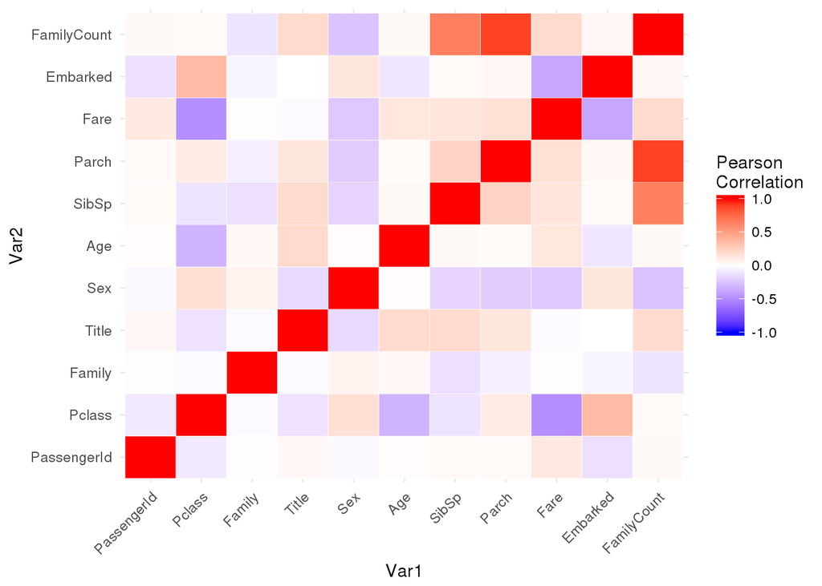

```r
fareCorMat <- as.data.table(
  melt(
    cor(sapply(
      wholeDt[complete.cases(Age,
                             Fare,
                             Embarked) & Age > 30,
              -c("Survived","CabinLetter", "CabinNumber"),
              with = FALSE],
      as.numeric))))
ggplot(fareCorMat[], aes(x=Var1, y=Var2, fill=value)) +
  scale_fill_gradient2(low = "blue", high = "red", mid = "white",
   midpoint = 0, limit = c(-1,1), space = "Lab",
   name="Pearson\nCorrelation") +
  theme_minimal()+
  geom_tile(color = "white") +
  theme(axis.text.x = element_text(angle = 45, hjust = 1))
```

Since Cabin and Survived information are missing for this passenger we excluded it from the heatmap. We can see that as we supposed Pclass and Embarked do influence Fare but Sex, Age and having a Family also does. Let’s look at the Fare distibution for a related population

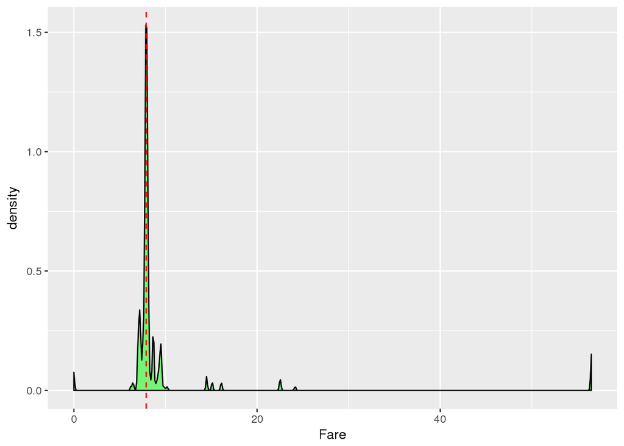

```r
ggplot(wholeDt[Sex == "male" &
                 Pclass == 3 &
                 Embarked == "S" &
                 FamilyCount == 1 &
                 !is.na(Fare)],
       aes(Fare)) +
  geom_density(fill = "green", alpha=0.5) +
  geom_vline(
    aes(xintercept = median(Fare, na.rm=T)),
    colour='red',
    linetype='dashed')
```

```r
wholeDt[PassengerId == 1044, Fare := wholeDt[Sex == "male" &
                                               Pclass == 3 &
                                               Embarked == "S" &
                                               FamilyCount == 1,
                                             median(Fare, na.rm=T)]]
```

Judging from this distribution it is safe to input the median value computed as Fare value for our Passenger 1044.

```r
normalize <- function(x) {
    return ((x - min(x)) / (max(x) - min(x)))
  }
```

```r
#trainDt <- as.data.table(sapply(trainDt[complete.cases(Age, Fare, Embarked)], normalize))
#testDt <- as.data.table(sapply(testDt, normalize))
#predSurv <- knn(train = trainDt, test = testDt, cl = trainDt[, Survived], k = round(sqrt(nrow(trainDt))))
```